# R Notebook

## ggplot2 further practice

We will be using a Breast cancer biopsy data-set from the Wisconsin Hospitals. This is available from a package called MASS so you will need to install & load it along with the tidyverse package.

```r
install.packages("tidyverse")
```

```
Error in install.packages : Updating loaded packages
```

```r
install.packages("MASS")
```

```
Error in install.packages : Updating loaded packages
```

```r
library(tidyverse)
library(MASS)
```

The MASS package loads functions and dataframes. The dataframe of interest is called biopsy. Use the R help function to find out more about this data frame and then you should examine a few rows of the data and observe the data types for each column.

```r
?biopsy

biopsy
```

|  | ID | V1 | V2 | V3 | V4 | V5 | V6 | V7 | V8 | V9 | class |
| --- | --- | --- | --- | --- | --- | --- | --- | --- | --- | --- | --- |
| 1 | 1000025 | 5 | 1 | 1 | 1 | 2 | 1 | 3 | 1 | 1 | benign |
| 2 | 1002945 | 5 | 4 | 4 | 5 | 7 | 10 | 3 | 2 | 1 | benign |
| 3 | 1015425 | 3 | 1 | 1 | 1 | 2 | 2 | 3 | 1 | 1 | benign |
| 4 | 1016277 | 6 | 8 | 8 | 1 | 3 | 4 | 3 | 7 | 1 | benign |
| 5 | 1017023 | 4 | 1 | 1 | 3 | 2 | 1 | 3 | 1 | 1 | benign |
| 6 | 1017122 | 8 | 10 | 10 | 8 | 7 | 10 | 9 | 7 | 1 | malignant |
| 7 | 1018099 | 1 | 1 | 1 | 1 | 2 | 10 | 3 | 1 | 1 | benign |
| 8 | 1018561 | 2 | 1 | 2 | 1 | 2 | 1 | 3 | 1 | 1 | benign |
| 9 | 1033078 | 2 | 1 | 1 | 1 | 2 | 1 | 1 | 1 | 5 | benign |
| 10 | 1033078 | 4 | 2 | 1 | 1 | 2 | 1 | 2 | 1 | 1 | benign |

[output cut: 689 more lines]

There are 699 rows of data. We can start by visualising the relative numbers of benign & malignant tumours using a bar-plot (try colouring the bars).

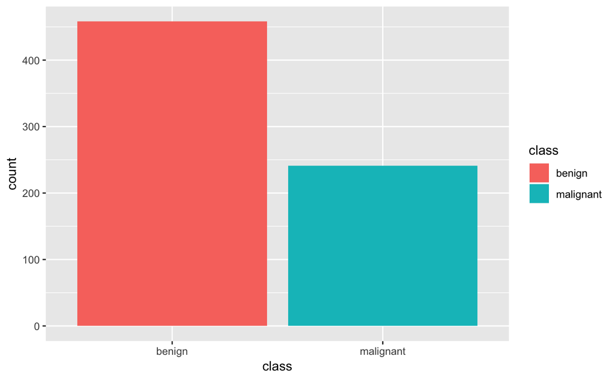

```r
ggplot(data=biopsy) + geom_bar(mapping = aes(x = class, fill = class))
```

Let’s now produce some histograms to explore the distribution of some of our datasets variables. Try clump thickness & then normal nuclei. Explore effects of various bin numbers and binwidths (use ?ggplot to get some hints)

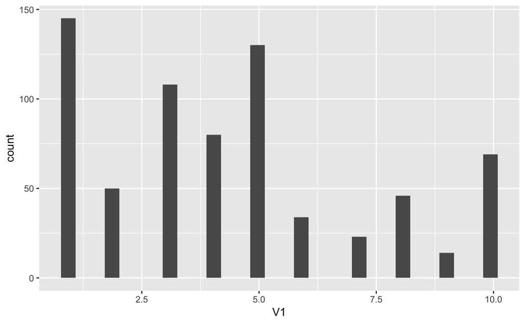

```r
ggplot(data=biopsy) + geom_histogram(mapping=aes(x=V1))
```

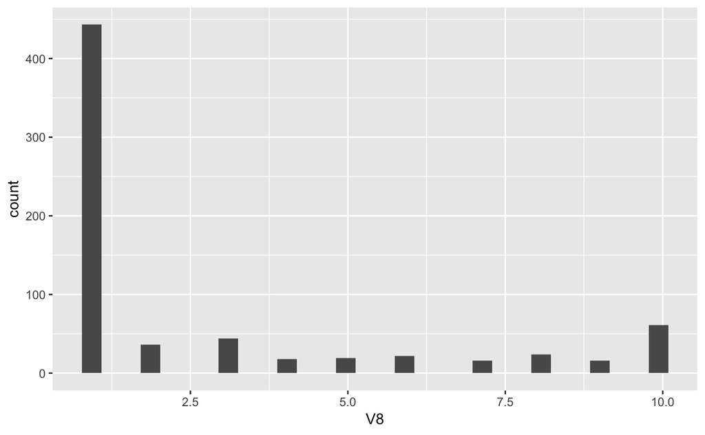

```r
ggplot(data=biopsy) + geom_histogram(mapping=aes(x=V8))
```

How might we split (or facet - hint,hint) our data into two plots one for benign and one for malignant? (You may need to use the R help function).

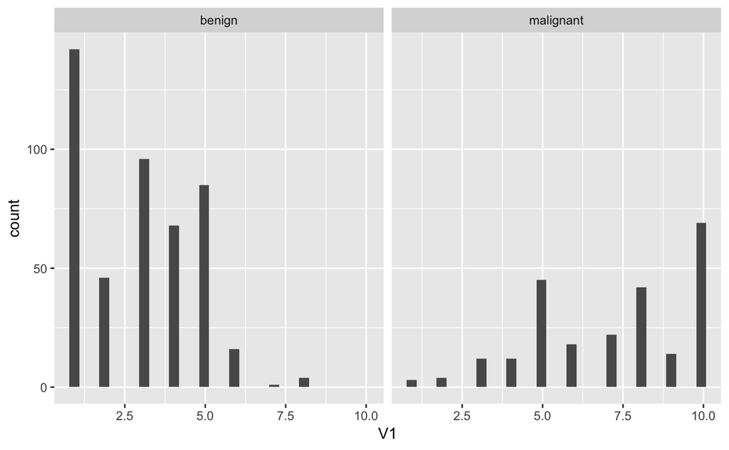

```r
ggplot(data=biopsy) + geom_histogram(mapping=aes(x=V1)) + facet_grid(cols=vars(class))
```

Let’s now explore the data variability of clump thickness in benign and malignant cases using a box-plot. Feel free to plot the other variables e.g. uniformity.

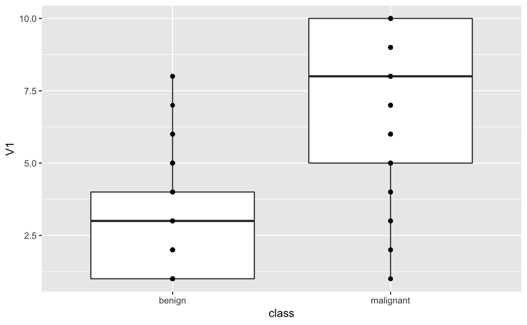

```r
ggplot(data=biopsy, mapping= aes(x=class, y=V1)) + geom_boxplot() + geom_point()
```

Try and improve this plot using jitter to see how much overlapping is present.

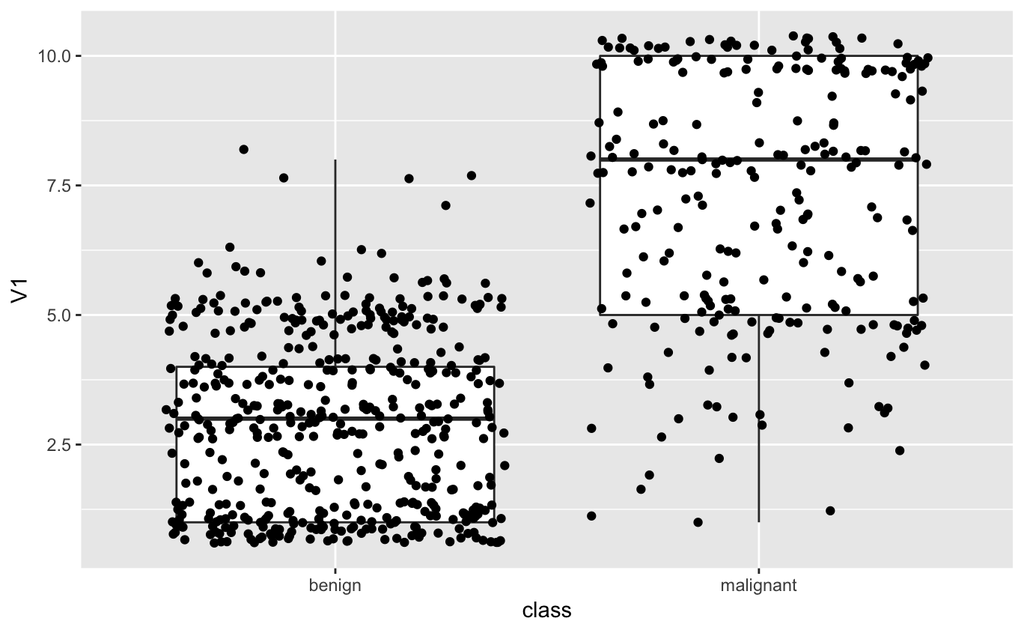

```r
ggplot(data=biopsy, mapping= aes(x=class, y=V1)) + geom_boxplot() + geom_jitter()
```

OK - so that’s a bit messy maybe we’d be better off with a violin plot?

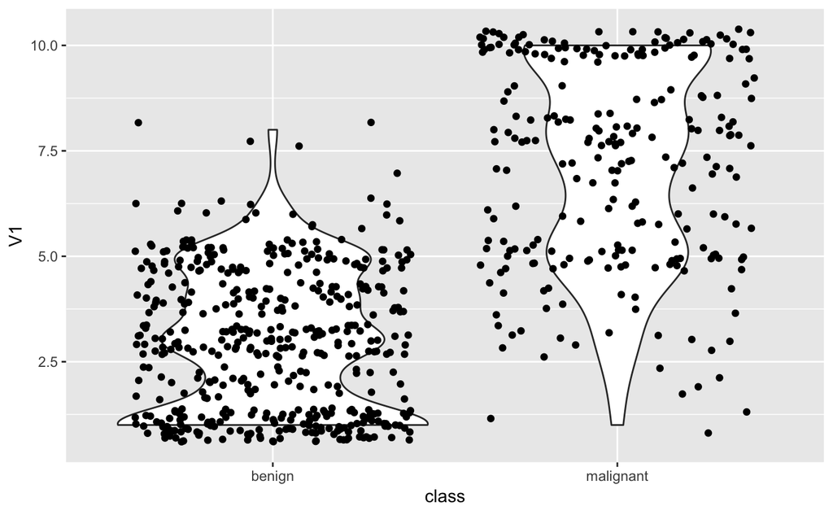

```r
ggplot(data=biopsy, mapping= aes(x=class, y=V1)) + geom_violin() + geom_jitter()
```